# 0625 practice

#### A회사의 건전지의 수명시간이 1000시간 일 때, 무작위로 뽑은 10개의 건전지에 대한 수명은 다음과 같다. {980, 1008, 968, 1032, 1012, 996, 1021, 1002, 996, 1017} 샘플이 모집단과 같다고 할 수 있는가?

```r
sample <- c(980, 1008, 968, 1032, 1012, 996, 1021, 1002, 996, 1017)
mu_0 <- 1000
t <- t.test(sample, mu =mu_0) ; t
```

```
##
##  One Sample t-test
##
## data:  sample
## t = 0.5269, df = 9, p-value = 0.611
## alternative hypothesis: true mean is not equal to 1000
## 95 percent confidence interval:
##   989.4613 1016.9387
## sample estimates:
## mean of x
##    1003.2
```

```r
# 결론
cat(paste(" A 회사의 건전지 수명시간 평균이 1000시간이다는 가정이 참인지 알아보기 위해", "\n",
          "무작위로 뽑은 표본 집단 {980, 1008, 968, 1032, 1012, 996, 1021, 1002, 996, 1017}의 수명을 측정하였습니다.", "\n",
          "표본의 평균은 ", round(mean(sample), 3), "(시간), 표준편차는 ", round(sd(sample),3),"(시간) 으로", "\n",
          "표본과 모집단을 비교하여 one sample t-test 를 한 결과\n 검정통계량",
          "t=", round(t$statistic, 3) , " (p-value: ", round(t$p.value, 3), ") 이며 95% 신뢰구간은 " ,
          round(t$conf.int[1],3),  "< mu <", round(t$conf.int[2], 3) ,"입니다.", "\n",
          "따라서, A 회사의 건전지 수명시간 평균이 1000시간이다 는 통계적으로 유의미한 결론으로 판단됩니다."))
```

```
##  A 회사의 건전지 수명시간 평균이 1000시간이다는 가정이 참인지 알아보기 위해
##  무작위로 뽑은 표본 집단 {980, 1008, 968, 1032, 1012, 996, 1021, 1002, 996, 1017}의 수명을 측정하였습니다.
##  표본의 평균은  1003.2 (시간), 표준편차는  19.205 (시간) 으로
##  표본과 모집단을 비교하여 one sample t-test 를 한 결과
##  검정통계량 t= 0.527  (p-value:  0.611 ) 이며 95% 신뢰구간은  989.461 < mu < 1016.939 입니다.
##  따라서, A 회사의 건전지 수명시간 평균이 1000시간이다 는 통계적으로 유의미한 결론으로 판단됩니다.
```

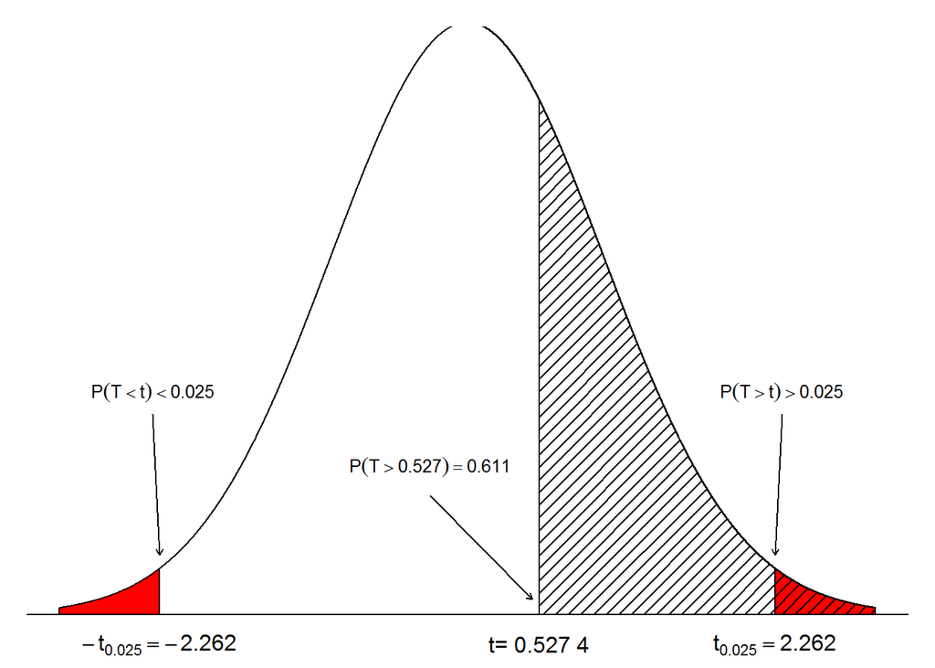

```r
# 그래프
par ( mar=c(0,1,1,1))
x <- seq(-3,3,by = 0.0001)
y <- dt (x, df=n-1)
plot(x, y, type = "l", axes = F, ylim = c(-0.02, 0.38),
     main = "", xlab = "t", ylab = "")
abline (h=0)
alpha <- 0.05
c.l <- qt(alpha/2, df = length(sample)-1) ;  c.u <- qt(1-alpha/2, df = length(sample)-1)
polygon (c(-3,  x[x<c.l] , c.l), c(0,y[x<c.l], 0), col=2)
polygon (c(c.u,  x[x>c.u] , 3), c(0,y[x>c.u], 0), col=2)
# round( qt(0.025, df=9),3) ; round( qt(0.975, df=9),3)
text (c.l, -0.02, expression(-t[0.025] == -2.262))
text (c.u, -0.02, expression(t[0.025] == 2.262))
text (c.l-0.05, 0.15, expression(P(T<t) <0.025), cex = 0.8)
text (c.u+0.05, 0.15, expression(P(T>t) >0.025), cex = 0.8)
arrows (c.l-0.05, 0.135, c.l, 0.04, length = 0.05)
arrows (c.u+0.05, 0.135, c.u, 0.04, length = 0.05)

t.t <- t$statistic
polygon (c(t.t, x[x>t.t], 3), c(0,y[x>t.t], 0), density=15, angle =45)
text (t.t, -0.02, paste("t=", round(t.t, 3), pos=4))
text (t.t-0.8, 0.1, expression(plain(P) (T>0.527) == 0.611), cex = 0.8)
arrows (t.t-0.8, 0.08, t.t-0.05 , 0.01, length = 0.05)
```

#### 어떤 반의 학생들의 수학 평균성적은 55점이었다. 0교시 수업을 시행하고 나서 학생들의 시험 성적은 다음과 같다. {58, 49, 39, 99, 32, 88, 62, 30, 55, 65, 44, 55, 57, 53, 88, 42, 39} 0교시 수업을 시행한 후, 학생들의 성적은 올랐다고 할 수 있는가?

```r
sample <- c(58, 49, 39, 99, 32, 88, 62, 30, 55, 65, 44, 55, 57, 53, 88, 42, 39)
mu_0 <- 55
t <- t.test(sample, mu =mu_0, alternative = "greater")

# 결론
cat(paste(" 0 교시 수업 시행 후 학생들의 수학 평균성적은 55점으로 변동하지 않는다 는 가정이 참인지 알아보기 위해", "\n",
          "표본 집단 {58, 49, 39, 99, 32, 88, 62, 30, 55, 65, 44, 55, 57, 53, 88, 42, 39}의 시험 성적을 분석하였습니다.", "\n",
          "평균은", round(mean(sample), 3), "(점), 표준편차는", round(sd(sample),3),"(점) 으로, 표본과 모집단을 비교하여 one-sided & one-sample t-test 를 한 결과\n 검정통계량 ",
          "t=", round(t$statistic, 3) , " (p-value : ", round(t$p.value, 3), ") 이며 ",
          "95% 신뢰구간은" ,  round(t$conf.int[1],3),  "< mu <", round(t$conf.int[2], 3) ,"입니다.", "\n",
          "따라서, 0 교시 수업 시행 후 학생들의 수학 평균성적은 55점에서 오르지 않는다 는 통계적으로 유의미한 결론으로 판단됩니다."))
```

```
##  0 교시 수업 시행 후 학생들의 수학 평균성적은 55점으로 변동하지 않는다 는 가정이 참인지 알아보기 위해
##  표본 집단 {58, 49, 39, 99, 32, 88, 62, 30, 55, 65, 44, 55, 57, 53, 88, 42, 39}의 시험 성적을 분석하였습니다.
##  평균은 56.176 (점), 표준편차는 19.762 (점) 으로, 표본과 모집단을 비교하여 one-sided & one-sample t-test 를 한 결과
##  검정통계량  t= 0.245  (p-value :  0.405 ) 이며  95% 신뢰구간은 47.809 < mu < Inf 입니다.
##  따라서, 0 교시 수업 시행 후 학생들의 수학 평균성적은 55점에서 오르지 않는다 는 통계적으로 유의미한 결론으로 판단됩니다.
```

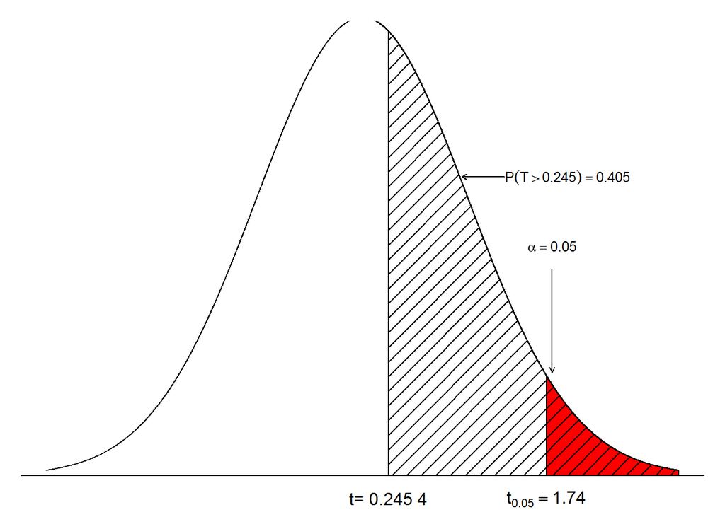

```r
# 그래프
par ( mar=c(0,1,1,1))
x <- seq(-3,3,by = 0.0001)
y <- dt (x, df=n-1)
plot(x, y, type = "l", axes = F, ylim = c(-0.02, 0.38),
     main = "", xlab = "t", ylab = "")
abline (h=0)

alpha <- 0.05 ; c.u <- qt(1-alpha, df = length(sample)-1)
polygon (c(c.u,  x[x>c.u] , 3), c(0,y[x>c.u], 0), col=2)
text (c.u, -0.02, expression(t[0.05] == 1.74))
text (1.8, 0.2, expression(alpha==0.05), cex = 0.8)
arrows (1.8, 0.18, 1.8, 0.09, length = 0.05)

t.t <- t$statistic
# t.t ; t$p.value
polygon (c(t.t, x[x>t.t], 3), c(0,y[x>t.t], 0), density=10, angle =45)
text (t.t, -0.02, paste("t=", round(t.t, 3), pos=4))
text (t.t+1.7, 0.26, expression(plain(P) (T>0.245) == 0.405), cex = 0.8)
arrows (t.t+1.1, 0.26, t.t+0.7, 0.26, length = 0.05)
```

#### 2006년 조사에 의하면 한국인의 1인 1일 평균 알코올 섭취량이 8.1g 이다. 2008년 무작위로 뽑은 알코올 섭취량은 다음과 같다. {15.50, 11.21, 12.67, 8.87, 12.15, 9.88, 2.06, 14.50, 0, 4.97} 평균 알코올 섭취량이 달라졌다고 할 수 있는가?

```r
sample <- c(15.50, 11.21, 12.67, 8.87, 12.15, 9.88, 2.06, 14.50, 0, 4.97)
mu_0 <- 8.1
t <- t.test(sample, mu =mu_0)

cat(paste(" 2008 년 한국인의 1인 1일 알코올 섭취량 평균이 8.1g 이다 는 가정이 참인지 알아보기 위해", "\n",
          "무작위로 뽑은 표본 집단 {15.50, 11.21, 12.67, 8.87, 12.15, 9.88, 2.06, 14.50, 0, 4.97} 을 분석하였습니다.", "\n",
          "평균은", round(mean(sample), 3), "(g), 표준편차는", round(sd(sample),3),"(g) 으로, 표본과 모집단을 비교하여 one sample t-test 를 한 결과\n 검정통계량 ",
          "t=", round(t$statistic, 3) , " (p-value : ", round(t$p.value, 3), ") 이며 ",
          "95% 신뢰구간은" ,  round(t$conf.int[1],3),  "< mu <", round(t$conf.int[2], 3) ,"입니다.", "\n",
          "따라서, 2008 년 한국인의 1인 1일 알코올 섭취량 평균은 8.1g 이다 는 통계적으로 유의미한 결론으로 판단됩니다."))
```

```
##  2008 년 한국인의 1인 1일 알코올 섭취량 평균이 8.1g 이다 는 가정이 참인지 알아보기 위해
##  무작위로 뽑은 표본 집단 {15.50, 11.21, 12.67, 8.87, 12.15, 9.88, 2.06, 14.50, 0, 4.97} 을 분석하였습니다.
##  평균은 9.181 (g), 표준편차는 5.235 (g) 으로, 표본과 모집단을 비교하여 one sample t-test 를 한 결과
##  검정통계량  t= 0.653  (p-value :  0.53 ) 이며  95% 신뢰구간은 5.436 < mu < 12.926 입니다.
##  따라서, 2008 년 한국인의 1인 1일 알코올 섭취량 평균은 8.1g 이다 는 통계적으로 유의미한 결론으로 판단됩니다.
```

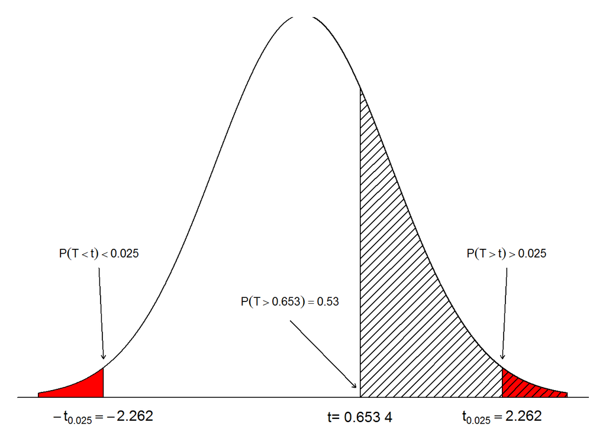

```r
# 그래프
par ( mar=c(0,1,1,1))
x <- seq(-3,3,by = 0.0001)
y <- dt (x, df=n-1)
plot(x, y, type = "l", axes = F, ylim = c(-0.02, 0.38),
     main = "", xlab = "t", ylab = "")
abline (h=0)
alpha <- 0.05
c.l <- qt(alpha/2, df = length(sample)-1) ;  c.u <- qt(1-alpha/2, df = length(sample)-1)
polygon (c(-3,  x[x<c.l] , c.l), c(0,y[x<c.l], 0), col=2)
polygon (c(c.u,  x[x>c.u] , 3), c(0,y[x>c.u], 0), col=2)
# round( qt(0.025, df=9),3) ; round( qt(0.975, df=9),3)
text (c.l, -0.02, expression(-t[0.025] == -2.262))
text (c.u, -0.02, expression(t[0.025] == 2.262))
text (c.l-0.05, 0.15, expression(P(T<t) <0.025), cex = 0.8)
text (c.u+0.05, 0.15, expression(P(T>t) >0.025), cex = 0.8)
arrows (c.l-0.05, 0.135, c.l, 0.04, length = 0.05)
arrows (c.u+0.05, 0.135, c.u, 0.04, length = 0.05)

t.t <- t$statistic
polygon (c(t.t, x[x>t.t], 3), c(0,y[x>t.t], 0), density=15, angle =45)
text (t.t, -0.02, paste("t=", round(t.t, 3), pos=4))
text (t.t-0.8, 0.1, expression(plain(P) (T>0.653) == 0.530), cex = 0.8)
arrows (t.t-0.8, 0.08, t.t-0.05 , 0.01, length = 0.05)
```

[output not shown]